# SL_Notebook

```python
import numpy as np
from sklearn.linear_model import LinearRegression
import pandas as pd
import matplotlib.pyplot as plt
%matplotlib inline
import seaborn as sns
from sklearn.model_selection import train_test_split # Sklearn package's randomized data splitting function
from sklearn.neighbors import KNeighborsClassifier
```

Part 1. 1 a - Read all the 3 CSV files as DataFrame and store them into 3 separate variables

```python
type_s = pd.read_csv("Type_S.csv")
type_h = pd.read_csv("Type_H.csv")
normal = pd.read_csv("Normal.csv")
```

Part 1.1 b - Print Shape and columns of all the 3 DataFrames

```python
print('shape of Type_S', type_s.shape)
print('Columns of Type_S')
type_s.info()
```

```
shape of Type_S (150, 7)
Columns of Type_S
<class 'pandas.core.frame.DataFrame'>
RangeIndex: 150 entries, 0 to 149
Data columns (total 7 columns):
 #   Column       Non-Null Count  Dtype
---  ------       --------------  -----
 0   P_incidence  150 non-null    float64
 1   P_tilt       150 non-null    float64
 2   L_angle      150 non-null    float64
 3   S_slope      150 non-null    float64
 4   P_radius     150 non-null    float64
 5   S_Degree     150 non-null    float64
 6   Class        150 non-null    object
dtypes: float64(6), object(1)
memory usage: 8.3+ KB
```

```python
print('shape of Type_H', type_h.shape)
print('Columns of Type_H')
type_h.info()
```

```
shape of Type_H (60, 7)
Columns of Type_H
<class 'pandas.core.frame.DataFrame'>
RangeIndex: 60 entries, 0 to 59
Data columns (total 7 columns):
 #   Column       Non-Null Count  Dtype
---  ------       --------------  -----
 0   P_incidence  60 non-null     float64
 1   P_tilt       60 non-null     float64
 2   L_angle      60 non-null     float64
 3   S_slope      60 non-null     float64
 4   P_radius     60 non-null     float64
 5   S_Degree     60 non-null     float64
 6   Class        60 non-null     object
dtypes: float64(6), object(1)
memory usage: 3.4+ KB
```

```python
print('shape of Normal', normal.shape)
print('Columns of Normal')
normal.info()
```

```
shape of Normal (100, 7)
Columns of Normal
<class 'pandas.core.frame.DataFrame'>
RangeIndex: 100 entries, 0 to 99
Data columns (total 7 columns):
 #   Column       Non-Null Count  Dtype
---  ------       --------------  -----
 0   P_incidence  100 non-null    float64
 1   P_tilt       100 non-null    float64
 2   L_angle      100 non-null    float64
 3   S_slope      100 non-null    float64
 4   P_radius     100 non-null    float64
 5   S_Degree     100 non-null    float64
 6   Class        100 non-null    object
dtypes: float64(6), object(1)
memory usage: 5.6+ KB
```

Part 1.1 c - Compare Column names of all the 3 DataFrames and clearly write observations

## Normal

Note: For all the 3 datasets, columns names are same.

Part 1.1 d - Print DataTypes of all the 3 DataFrames.

```python
dtype_type_s = type_s.dtypes
dtype_type_s
```

```
P_incidence    float64
P_tilt         float64
L_angle        float64
S_slope        float64
P_radius       float64
S_Degree       float64
Class           object
dtype: object
```

```python
dtype_type_h = type_h.dtypes
dtype_type_h
```

```
P_incidence    float64
P_tilt         float64
L_angle        float64
S_slope        float64
P_radius       float64
S_Degree       float64
Class           object
dtype: object
```

```python
dtype_normal = normal.dtypes
dtype_normal
```

```
P_incidence    float64
P_tilt         float64
L_angle        float64
S_slope        float64
P_radius       float64
S_Degree       float64
Class           object
dtype: object
```

Part 1.1 e - Observe and share variation in ‘Class’ feature of all the 3 DaraFrames

```python
print(type_s['Class'].unique())
print(type_h['Class'].unique())
print(normal['Class'].unique())
```

```
['Type_S' 'tp_s']
['Type_H' 'type_h']
['Normal' 'Nrmal']
```

## Type_S

There are 2 possible values ['Type_S' 'tp_s']

## Type_H

There are 2 possible values ['Type_H' 'type_h']

## Normal

There are 2 possible values ['Normal' 'Nrmal']

Part 1.2 a - Unify all the variations in ‘Class’ feature for all the 3 DataFrames

```python
normal = normal.replace(to_replace ='Nrmal', value = 'Normal', regex = True)
print(normal['Class'].unique())
type_s = type_s.replace(to_replace ='Type_S', value = 'type_s', regex = True)
type_s = type_s.replace(to_replace ='tp_s', value = 'type_s', regex = True)
print(type_s['Class'].unique())
type_h = type_h.replace(to_replace ='Type_H', value = 'type_h', regex = True)
type_h = type_h.replace(to_replace ='tp_h', value = 'type_h', regex = True)
print(type_h['Class'].unique())
```

```
['Normal']
['type_s']
['type_h']
```

Part 1.2 b - Combine all the 3 DataFrames to form a single DataFrame

```python
df = [normal, type_s, type_h]
final_df = pd.concat(df)
final_df.shape
```

```
(310, 7)
```

Part 1.2 c - Print 5 random samples of this DataFrame

```python
final_df.sample(n=5)
```

|  | P_incidence | P_tilt | L_angle | S_slope | P_radius | S_Degree | Class |
| --- | --- | --- | --- | --- | --- | --- | --- |
| 73 | 48.995958 | 13.113820 | 51.873520 | 35.882137 | 126.398188 | 0.535472 | Normal |
| 53 | 30.149936 | 11.917445 | 34.000000 | 18.232491 | 112.684141 | 11.463223 | type_h |
| 88 | 66.507179 | 20.897672 | 31.727471 | 45.609507 | 128.902905 | 1.517203 | Normal |
| 127 | 60.419932 | 5.265665 | 59.814236 | 55.154267 | 109.033074 | 30.265785 | type_s |
| 44 | 56.030218 | 16.297915 | 62.275275 | 39.732303 | 114.023117 | -2.325684 | type_h |

Part 1.2 d - Print Feature-wise percentage of Null values

```python
null_percentage = final_df.isnull().mean() * 100
print(null_percentage)
```

```
P_incidence    0.0
P_tilt         0.0
L_angle        0.0
S_slope        0.0
P_radius       0.0
S_Degree       0.0
Class          0.0
dtype: float64
```

No missing values in the dataset

Part 1.2 e - Check 5-point summary of the new DataFrame

```python
final_df.describe().T
```

|  | count | mean | std | min | 25% | 50% | 75% | max |
| --- | --- | --- | --- | --- | --- | --- | --- | --- |
| P_incidence | 310.0 | 60.496653 | 17.236520 | 26.147921 | 46.430294 | 58.691038 | 72.877696 | 129.834041 |
| P_tilt | 310.0 | 17.542822 | 10.008330 | -6.554948 | 10.667069 | 16.357689 | 22.120395 | 49.431864 |
| L_angle | 310.0 | 51.930930 | 18.554064 | 14.000000 | 37.000000 | 49.562398 | 63.000000 | 125.742385 |
| S_slope | 310.0 | 42.953831 | 13.423102 | 13.366931 | 33.347122 | 42.404912 | 52.695888 | 121.429566 |
| P_radius | 310.0 | 117.920655 | 13.317377 | 70.082575 | 110.709196 | 118.268178 | 125.467674 | 163.071041 |
| S_Degree | 310.0 | 26.296694 | 37.559027 | -11.058179 | 1.603727 | 11.767934 | 41.287352 | 418.543082 |

Part 1.3 a - Visualize a heatmap to understand correlation between all features

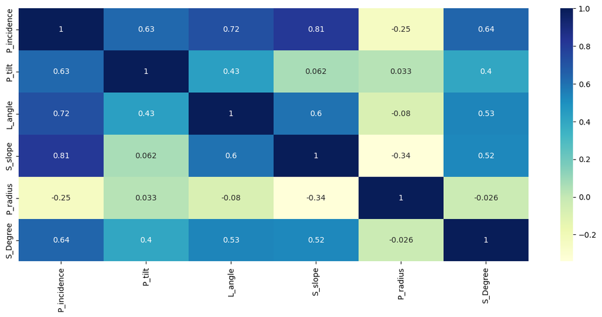

```python
plt.figure(figsize=(15,6))
sns.heatmap(final_df.corr(), cmap='YlGnBu', annot=True)
plt.xticks(rotation=90)
plt.show()
```

Part 1.3 b - Share insights on correlation

A. Features having stronger correlation with correlation value.

1. P_incidence has high correlation with S_slope with a value of 0.81
2. P_incidence has high correlation with L_angle with a value of 0.72

B. Features having weaker correlation with correlation value.

1. P_radius has weak negative correlation with S_Degree with a value of -0.026
2. P_incidence has weak negative correlation with P_radius with a value of -0.25

Part 1.3 c - Visualize a pairplot with 3 classes distinguished by colors and share insights

```python
#Resetting the indexes for the merged dataframe
final_df = final_df.reset_index(drop=True)
```

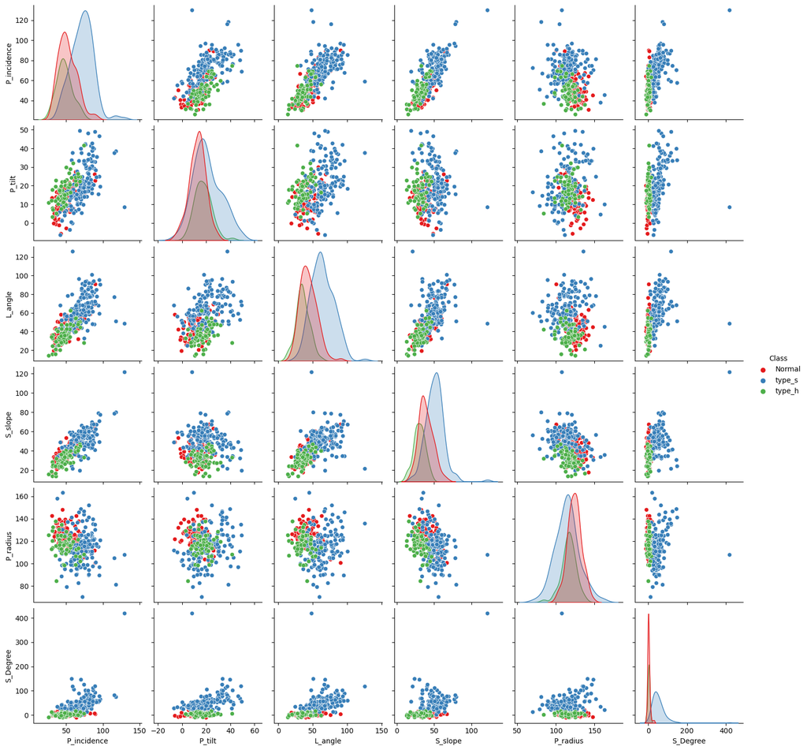

```python
plt.figure(figsize=(15,6))
sns.pairplot(final_df, hue='Class', palette='Set1')
plt.show()
```

## Insights

P_tilt has positive correlation with P_incidence and L_angle.

L_angle has positive correlation with P_incidence, P_tilt and s_slope.

S_slope has positive correlation with P_incidence and L_angle and negative correlation with p_radius

On diagonal, the distribution of 3 classes is not same

```python
final_df.head()
```

|  | P_incidence | P_tilt | L_angle | S_slope | P_radius | S_Degree | Class |
| --- | --- | --- | --- | --- | --- | --- | --- |
| 0 | 38.505273 | 16.964297 | 35.112814 | 21.540976 | 127.632875 | 7.986683 | Normal |
| 1 | 54.920858 | 18.968430 | 51.601455 | 35.952428 | 125.846646 | 2.001642 | Normal |
| 2 | 44.362490 | 8.945435 | 46.902096 | 35.417055 | 129.220682 | 4.994195 | Normal |
| 3 | 48.318931 | 17.452121 | 48.000000 | 30.866809 | 128.980308 | -0.910941 | Normal |
| 4 | 45.701789 | 10.659859 | 42.577846 | 35.041929 | 130.178314 | -3.388910 | Normal |

Part 1.3 d - Visualize a jointplot for ‘P_incidence’ and ‘S_slope’ and share insights

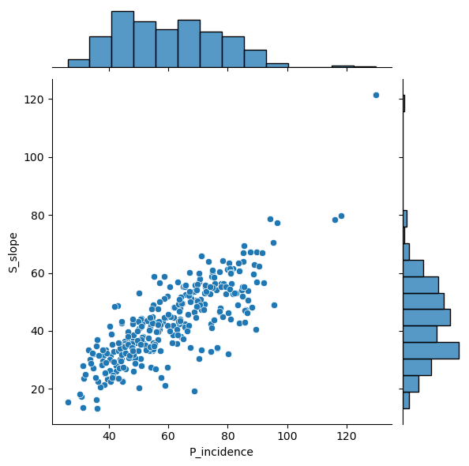

```python
sns.jointplot(x='P_incidence', y='S_slope', data=final_df, kind='scatter')
plt.show()
```

P_incidence and s_slope having positive correlation.

Part 1.3 e - Visualize a boxplot to check distribution of the features and share insights.

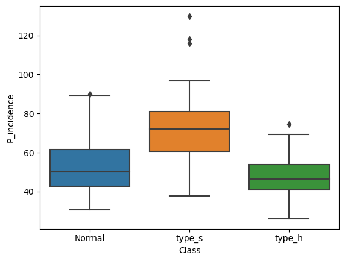

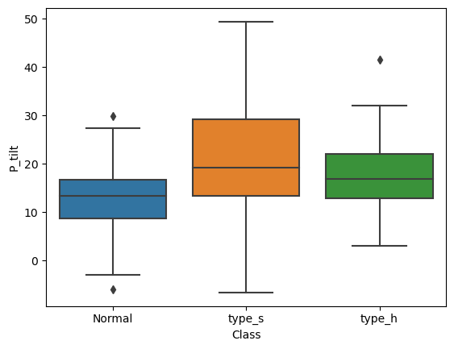

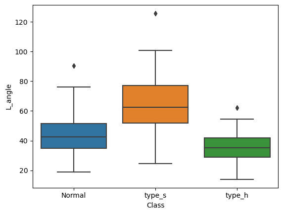

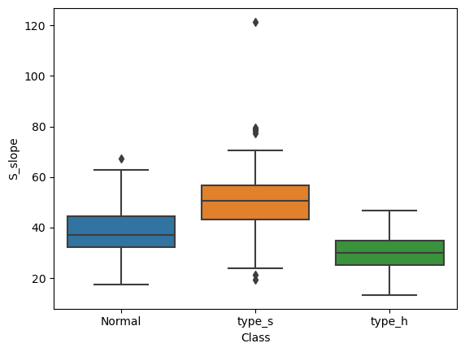

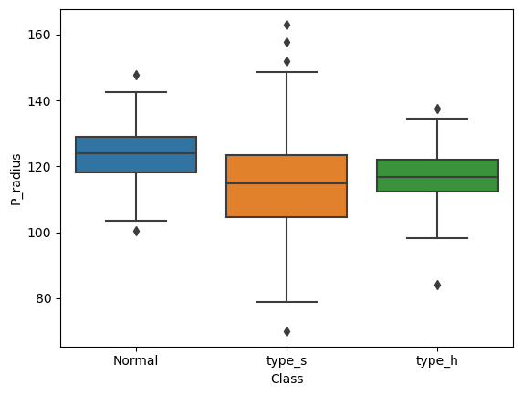

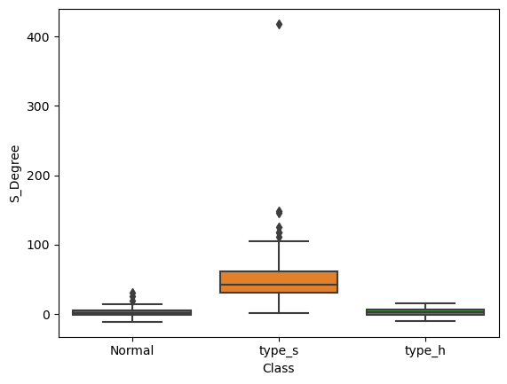

```python
for column in final_df.columns:
    if column != 'Class':
        sns.boxplot(x='Class', y=column, data= final_df)
        plt.show()
```

From the boxplots for each column and class, we do see outliers. Need to impute them

```python
for c in final_df.columns:
    if c != 'Class':
        q25, q75 = np.percentile(final_df[c], [25, 75])
        IQR = q75 - q25
        threshold = IQR * 1.5
        lower, upper = q25 - threshold, q75 + threshold

        outliers_before = final_df[(final_df[c] < lower) | (final_df[c] > upper)]

        df_include = final_df[(final_df[c] >= lower) & (final_df[c] <= upper)]
        mean = df_include[c].mean()

        final_df.loc[(final_df[c] < lower) | (final_df[c] > upper), c] = mean

        outliers_after = final_df[(final_df[c] < lower) | (final_df[c] > upper)]
```

Part 1.4 a - Split data into X and Y.

```python
final_df['Class'].value_counts()
```

```
type_s    150
Normal    100
type_h     60
Name: Class, dtype: int64
```

```python
final_df['Class']=final_df['Class'].astype('category') #changing to category datatype
```

```python
#split the dataset into training and test datasets
import numpy as np
from sklearn.model_selection import train_test_split
from scipy.stats import zscore


# Transform data into features and target
X=final_df.drop(columns='Class')
y=final_df['Class'] #target
XScaled  = X.apply(zscore)  # convert all attributes to Z scale

XScaled.describe()
```

|  | P_incidence | P_tilt | L_angle | S_slope | P_radius | S_Degree |
| --- | --- | --- | --- | --- | --- | --- |
| count | 3.100000e+02 | 3.100000e+02 | 3.100000e+02 | 3.100000e+02 | 3.100000e+02 | 3.100000e+02 |
| mean | -1.908867e-16 | -2.318934e-17 | -5.074794e-16 | 1.017108e-16 | -1.172181e-15 | 2.327887e-16 |
| std | 1.001617e+00 | 1.001617e+00 | 1.001617e+00 | 1.001617e+00 | 1.001617e+00 | 1.001617e+00 |
| min | -2.094776e+00 | -2.672132e+00 | -2.089136e+00 | -2.321380e+00 | -2.539411e+00 | -1.320282e+00 |
| 25% | -8.360712e-01 | -6.993178e-01 | -8.143284e-01 | -7.401670e-01 | -5.976486e-01 | -8.176298e-01 |
| 50% | -7.518077e-02 | -1.828444e-02 | -1.180394e-01 | -2.334223e-02 | -2.509895e-15 | -4.141310e-01 |
| 75% | 7.702029e-01 | 5.302470e-01 | 6.248067e-01 | 7.736237e-01 | 6.298674e-01 | 6.329680e-01 |
| max | 2.280971e+00 | 2.643481e+00 | 2.718787e+00 | 2.927772e+00 | 2.508199e+00 | 3.100103e+00 |

Part 1.4 b - Split data into train and test with 80:20 proportion

```python
# split into train and test
X_train, X_test, y_train, y_test = train_test_split(X, y, test_size=0.20, random_state=10)
X_train
```

|  | P_incidence | P_tilt | L_angle | S_slope | P_radius | S_Degree |
| --- | --- | --- | --- | --- | --- | --- |
| 267 | 31.276012 | 3.144669 | 32.562996 | 28.131342 | 129.011418 | 3.623020 |
| 290 | 35.492446 | 11.701672 | 15.590363 | 23.790774 | 106.938852 | -3.460358 |
| 209 | 44.253476 | 1.101087 | 38.000000 | 43.152390 | 98.274107 | 23.910635 |
| 92 | 54.600316 | 21.488974 | 29.360216 | 33.111342 | 118.343321 | -1.471067 |
| 194 | 41.187770 | 5.792974 | 42.867392 | 35.394796 | 103.348880 | 27.660277 |
| ... | ... | ... | ... | ... | ... | ... |
| 156 | 70.484104 | 12.489488 | 62.417142 | 57.994617 | 114.190049 | 56.902448 |
| 123 | 81.104100 | 24.794168 | 77.887020 | 56.309932 | 118.063495 | 65.214616 |
| 15 | 59.726140 | 7.724873 | 55.343485 | 52.001268 | 125.174221 | 3.235159 |
| 125 | 45.443750 | 9.906072 | 45.000000 | 35.537678 | 118.063495 | 20.315315 |
| 265 | 44.318907 | 12.537992 | 36.098763 | 31.780915 | 124.115836 | 5.415825 |

248 rows × 6 columns

Part 1.4 c - Train a Supervised Learning Classification base model using KNN classifier

```python
NNH = KNeighborsClassifier(n_neighbors= 5 , metric = 'euclidean' )
NNH.fit(X_train, y_train)
predicted_labels = NNH.predict(X_test)
```

Part 1.4 d - Print all the possible performance metrics for both train and test data

```python
print('Accuracy on Training data:',NNH.score(X_train, y_train) )
print('Accuracy on Test data:',NNH.score(X_test, y_test) )
```

```
Accuracy on Training data: 0.9112903225806451
Accuracy on Test data: 0.7580645161290323
```

The difference in accuracy of train vs test data indicates overfitting.

```
Confusion Matrix
```

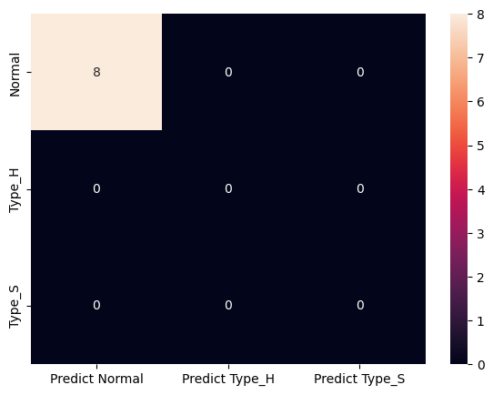

```python
# calculate accuracy measures and confusion matrix
from sklearn import metrics

print("Confusion Matrix")
cm=metrics.confusion_matrix(y_test, predicted_labels, labels= ["Normal", "Type_H", "Type_S"])

df_cm = pd.DataFrame(cm, index = [i for i in ["Normal", "Type_H", "Type_S"]],
                  columns = [i for i in ["Predict Normal","Predict Type_H","Predict Type_S"]])
plt.figure(figsize = (7,5))
sns.heatmap(df_cm, annot=True)
```

```python
from sklearn.metrics import classification_report
print("classification  Matrix:\n",classification_report(y_test,predicted_labels))
```

```
classification  Matrix:
               precision    recall  f1-score   support

      Normal       0.57      0.47      0.52        17
      type_h       0.43      0.50      0.46        12
      type_s       0.97      1.00      0.99        33

    accuracy                           0.76        62
   macro avg       0.66      0.66      0.65        62
weighted avg       0.76      0.76      0.76        62
```

Based on these insights, we can see that the classifier performs relatively well for the "Type_S" class with high precision, recall, and F1-score. However, it has lower performance for the "Normal" and "Type_H" classes, with lower precision, recall, and F1-score

As we increase K , training accuracy decreases

Part 1.5 a - Experiment with various parameters to improve performance of the base model

Part 1.5 b - Clearly showcase improvement in performance achieved

Part 1.5 c - Clearly state which parameters contributed most to improve model performance.

[output not shown]

[output cut: 72 more lines]

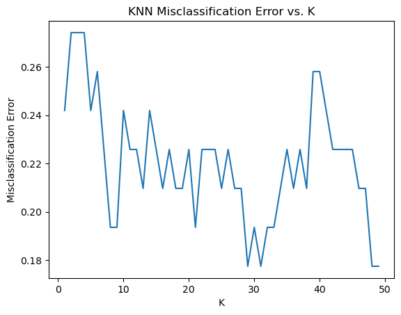

```python
from sklearn.metrics import accuracy_score
# Define a range of K values
k_values = range(1, 50)

misclassification_errors = []

# Calculate misclassification error for each K value
for k in k_values:
    # Train KNN classifier
    knn = KNeighborsClassifier(n_neighbors=k)
    knn.fit(X_train, y_train)

    # Predict labels for test set
    y_pred = knn.predict(X_test)

    # Calculate misclassification error
    error = 1 - accuracy_score(y_test, y_pred)
    misclassification_errors.append(error)

# Plot K values vs. misclassification error
plt.plot(k_values, misclassification_errors)
plt.xlabel('K')
plt.ylabel('Misclassification Error')
plt.title('KNN Misclassification Error vs. K')
plt.show()
```

```python
optimal_k = k_values[misclassification_errors.index(min(misclassification_errors))]
print("Optimal K value:", optimal_k)
knn = KNeighborsClassifier(n_neighbors=optimal_k)

# Fit the KNN model on the training data
knn.fit(X_train, y_train)

# Predict the target variable for the training and test data
train_predictions = knn.predict(X_train)
test_predictions = knn.predict(X_test)

# Calculate the accuracy on the training data
train_accuracy = accuracy_score(y_train, train_predictions)
print("Accuracy on Training data:", train_accuracy)

# Calculate the accuracy on the test data
test_accuracy = accuracy_score(y_test, test_predictions)
print("Accuracy on Test data:", test_accuracy)


print("classification  Matrix:\n",classification_report(y_test,test_predictions))
```

```
Optimal K value: 29
Accuracy on Training data: 0.842741935483871
Accuracy on Test data: 0.8225806451612904
classification  Matrix:
               precision    recall  f1-score   support

      Normal       0.67      0.71      0.69        17
      type_h       0.58      0.58      0.58        12
      type_s       1.00      0.97      0.98        33

    accuracy                           0.82        62
   macro avg       0.75      0.75      0.75        62
weighted avg       0.83      0.82      0.82        62
```

The updated classification matrix shows improvements in overall accuracy, precision, recall, and F1-score compared to the previous matrix. The model is performing better in correctly predicting the "Normal" and "type_h" classes, resulting in higher accuracy and balanced F1-scores.

Accuracy: The accuracy of the model has improved from 76% to 82%. This indicates that the model is making more correct predictions overall.

Note that having a optimal value of k contributed most in getting the best performance.

DOMAIN: Banking, Marketing • CONTEXT: A bank X is on a massive digital transformation for all its departments. Bank has a growing customer base whee majority of them are liability customers (depositors) vs borrowers (asset customers). The bank is interested in expanding the borrowers base rapidly to bring in more business via loan interests. A campaign that the bank ran in last quarter showed an average single digit conversion rate. Digital transformation being the core strength of the business strategy, marketing department wants to devise effective campaigns with better target marketing to increase the conversion ratio to double digit with same budget as per last campaign. • DATA DICTIONARY:

1. ID: Customer ID
2. Age: Customer’s approximate age.
3. CustomerSince: Customer of the bank since. [unit is masked]
4. HighestSpend: Customer’s highest spend so far in one transaction. [unit is masked]
5. ZipCode: Customer’s zip code.
6. HiddenScore: A score associated to the customer which is masked by the bank as an IP.
7. MonthlyAverageSpend: Customer’s monthly average spend so far. [unit is masked]
8. Level: A level associated to the customer which is masked by the bank as an IP.
9. Mortgage: Customer’s mortgage. [unit is masked]
10. Security: Customer’s security asset with the bank. [unit is masked]
11. FixedDepositAccount: Customer’s fixed deposit account with the bank. [unit is masked]
12. InternetBanking: if the customer uses internet banking.
13. CreditCard: if the customer uses bank’s credit card.
14. LoanOnCard: if the customer has a loan on credit card.

Part 2.1 a - Read both the Datasets ‘Data1’ and ‘Data 2’ as DataFrame and store them into two separate variables

```python
data1_df = pd.read_csv("Data1.csv")
data2_df = pd.read_csv("Data2.csv")
```

Part 2.1 b - Print shape and Column Names and DataTypes of both the Dataframes.

```python
print('Shape of Data1',data1_df.shape)
```

```
Shape of Data1 (5000, 8)
```

```python
print('Shape of Data2',data2_df.shape)
```

```
Shape of Data2 (5000, 7)
```

```python
print('Column names and Datatypes for Data1:')
data1_df.info()
```

```
Column names and Datatypes for Data1:
<class 'pandas.core.frame.DataFrame'>
RangeIndex: 5000 entries, 0 to 4999
Data columns (total 8 columns):
 #   Column               Non-Null Count  Dtype
---  ------               --------------  -----
 0   ID                   5000 non-null   int64
 1   Age                  5000 non-null   int64
 2   CustomerSince        5000 non-null   int64
 3   HighestSpend         5000 non-null   int64
 4   ZipCode              5000 non-null   int64
 5   HiddenScore          5000 non-null   int64
 6   MonthlyAverageSpend  5000 non-null   float64
 7   Level                5000 non-null   int64
dtypes: float64(1), int64(7)
memory usage: 312.6 KB
```

```python
print('Column names and Datatypes for Data2:')
data2_df.info()
```

```
Column names and Datatypes for Data2:
<class 'pandas.core.frame.DataFrame'>
RangeIndex: 5000 entries, 0 to 4999
Data columns (total 7 columns):
 #   Column               Non-Null Count  Dtype
---  ------               --------------  -----
 0   ID                   5000 non-null   int64
 1   Mortgage             5000 non-null   int64
 2   Security             5000 non-null   int64
 3   FixedDepositAccount  5000 non-null   int64
 4   InternetBanking      5000 non-null   int64
 5   CreditCard           5000 non-null   int64
 6   LoanOnCard           4980 non-null   float64
dtypes: float64(1), int64(6)
memory usage: 273.6 KB
```

Part 2.1 c - Merge both the Dataframes on ‘ID’ feature to form a single DataFrame

```python
merged_df = pd.merge(data1_df, data2_df, on='ID', how='outer')
merged_df
```

|  | ID | Age | CustomerSince | HighestSpend | ZipCode | HiddenScore | MonthlyAverageSpend | Level | Mortgage | Security | FixedDepositAccount | InternetBanking | CreditCard | LoanOnCard |
| --- | --- | --- | --- | --- | --- | --- | --- | --- | --- | --- | --- | --- | --- | --- |
| 0 | 1 | 25 | 1 | 49 | 91107 | 4 | 1.6 | 1 | 0 | 1 | 0 | 0 | 0 | NaN |
| 1 | 2 | 45 | 19 | 34 | 90089 | 3 | 1.5 | 1 | 0 | 1 | 0 | 0 | 0 | NaN |
| 2 | 3 | 39 | 15 | 11 | 94720 | 1 | 1.0 | 1 | 0 | 0 | 0 | 0 | 0 | NaN |
| 3 | 4 | 35 | 9 | 100 | 94112 | 1 | 2.7 | 2 | 0 | 0 | 0 | 0 | 0 | NaN |
| 4 | 5 | 35 | 8 | 45 | 91330 | 4 | 1.0 | 2 | 0 | 0 | 0 | 0 | 1 | NaN |
| ... | ... | ... | ... | ... | ... | ... | ... | ... | ... | ... | ... | ... | ... | ... |
| 4995 | 4996 | 29 | 3 | 40 | 92697 | 1 | 1.9 | 3 | 0 | 0 | 0 | 1 | 0 | 0.0 |
| 4996 | 4997 | 30 | 4 | 15 | 92037 | 4 | 0.4 | 1 | 85 | 0 | 0 | 1 | 0 | 0.0 |
| 4997 | 4998 | 63 | 39 | 24 | 93023 | 2 | 0.3 | 3 | 0 | 0 | 0 | 0 | 0 | 0.0 |
| 4998 | 4999 | 65 | 40 | 49 | 90034 | 3 | 0.5 | 2 | 0 | 0 | 0 | 1 | 0 | 0.0 |
| 4999 | 5000 | 28 | 4 | 83 | 92612 | 3 | 0.8 | 1 | 0 | 0 | 0 | 1 | 1 | 0.0 |

5000 rows × 14 columns

Part 2.1 d - Change Datatype of below features to ‘Object’‘CreditCard’, ‘InternetBanking’, ‘FixedDepositAccount’, ‘Security’, ‘Level’, ‘HiddenScore’. [Reason behind performing this operation:- Values in these features are binary i.e. 1/0. But DataType is ‘int’/’float’ which is not expected.]

```python
columns_to_convert = ['CreditCard', 'InternetBanking', 'FixedDepositAccount', 'Security', 'Level', 'HiddenScore']
for column in columns_to_convert:
    merged_df[column] = merged_df[column].astype('object')
print(merged_df.dtypes)
```

```
ID                       int64
Age                      int64
CustomerSince            int64
HighestSpend             int64
ZipCode                  int64
HiddenScore             object
MonthlyAverageSpend    float64
Level                   object
Mortgage                 int64
Security                object
FixedDepositAccount     object
InternetBanking         object
CreditCard              object
LoanOnCard             float64
dtype: object
```

Part 2.2 a - Visualize distribution of Target variable ‘LoanOnCard’ and clearly share insights

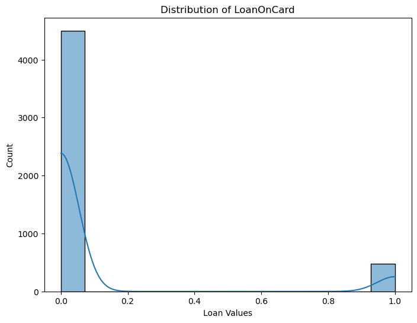

```python
plt.figure(figsize=(8, 6))
sns.histplot(data=merged_df, x='LoanOnCard', kde=True)
plt.title('Distribution of LoanOnCard')
plt.xlabel('Loan Values')
plt.ylabel('Count')
plt.show()
```

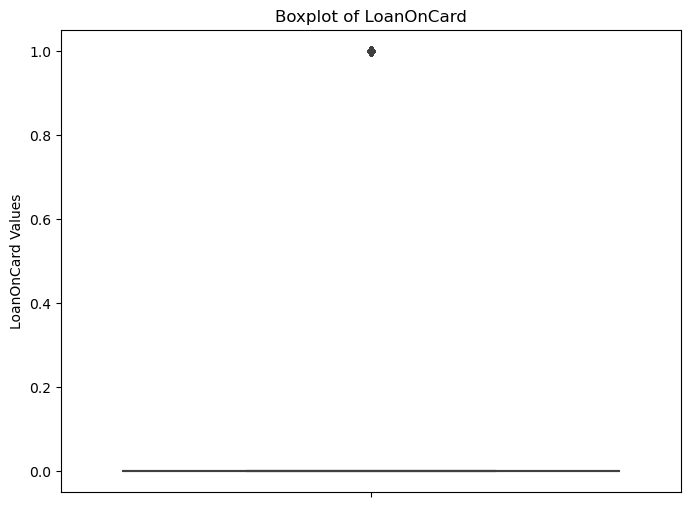

```python
plt.figure(figsize=(8, 6))
sns.boxplot(data=merged_df, y='LoanOnCard')
plt.title('Boxplot of LoanOnCard')
plt.ylabel('LoanOnCard Values')
plt.show()
```

## Insights

1. Data is highly right skewed.
2. The boxplot only shows outliers without any other elements (such as whiskers or a box), it might indicate that the majority of the data points in your dataset are concentrated within a narrow range, leaving only a few extreme values that are considered outliers.
3. The presence of outliers may suggest data quality issues, such as errors in data collection or measurement.
4. Outliers in loan on card data might arise due to incomplete or insufficient data coverage

```python
merged_df.groupby(["LoanOnCard"]).count()
```

| LoanOnCard | ID | Age | CustomerSince | HighestSpend | ZipCode | HiddenScore | MonthlyAverageSpend | Level | Mortgage | Security | FixedDepositAccount | InternetBanking | CreditCard |
| --- | --- | --- | --- | --- | --- | --- | --- | --- | --- | --- | --- | --- | --- |
| 0.0 | 4500 | 4500 | 4500 | 4500 | 4500 | 4500 | 4500 | 4500 | 4500 | 4500 | 4500 | 4500 | 4500 |
| 1.0 | 480 | 480 | 480 | 480 | 480 | 480 | 480 | 480 | 480 | 480 | 480 | 480 | 480 |

```python
merged_df.info()
```

```
<class 'pandas.core.frame.DataFrame'>
Int64Index: 5000 entries, 0 to 4999
Data columns (total 14 columns):
 #   Column               Non-Null Count  Dtype
---  ------               --------------  -----
 0   ID                   5000 non-null   int64
 1   Age                  5000 non-null   int64
 2   CustomerSince        5000 non-null   int64
 3   HighestSpend         5000 non-null   int64
 4   ZipCode              5000 non-null   int64
 5   HiddenScore          5000 non-null   object
 6   MonthlyAverageSpend  5000 non-null   float64
 7   Level                5000 non-null   object
 8   Mortgage             5000 non-null   int64
 9   Security             5000 non-null   object
 10  FixedDepositAccount  5000 non-null   object
 11  InternetBanking      5000 non-null   object
 12  CreditCard           5000 non-null   object
 13  LoanOnCard           4980 non-null   float64
dtypes: float64(2), int64(6), object(6)
memory usage: 585.9+ KB
```

```python
from scipy import stats

grouped_data = merged_df.groupby('LoanOnCard')

non_categorical_variables = ['Age', 'CustomerSince', 'HighestSpend', 'MonthlyAverageSpend', 'Mortgage', 'ZipCode' ]

group1 = merged_df[merged_df['LoanOnCard'] == 0]
group2 = merged_df[merged_df['LoanOnCard'] == 1]

# Perform t-test for each feature
for feature in non_categorical_variables:
    t_statistic, p_value = stats.ttest_ind(group1[feature], group2[feature])
    count = 0
    if p_value  < 0.05:
            print(feature,'has direct correlation with LoanOnCard')
    else:
            print(feature,'has no correlation with LoanOnCard')
```

```
Age has no correlation with LoanOnCard
CustomerSince has no correlation with LoanOnCard
HighestSpend has direct correlation with LoanOnCard
MonthlyAverageSpend has direct correlation with LoanOnCard
Mortgage has direct correlation with LoanOnCard
ZipCode has no correlation with LoanOnCard
```

```python
# Drop the columns Age,CustomerSince and ZipCode
merged_df.drop(['Age','CustomerSince','ZipCode'], axis=1,inplace=True)
merged_df.drop(['ID'], axis=1,inplace=True)
# Drop ID column as well. It is recommended in other questions
```

```python
# For categorical variables trying to see the correlation with Target variable
from scipy.stats import chi2_contingency
categorical_variables = ['HiddenScore','Level','Security','FixedDepositAccount','InternetBanking', 'CreditCard']
for feature in categorical_variables:
    contingency_table = pd.crosstab(merged_df[feature], merged_df['LoanOnCard'])
    chi2, p_value, dof, expected = chi2_contingency(contingency_table)
    count = 0
    if p_value  < 0.05:
            print(feature,'has direct correlation with LoanOnCard')
    else:
            print(feature,'has no correlation with LoanOnCard')
    print()
```

```
HiddenScore has direct correlation with LoanOnCard

Level has direct correlation with LoanOnCard

Security has no correlation with LoanOnCard

FixedDepositAccount has direct correlation with LoanOnCard

InternetBanking has no correlation with LoanOnCard

CreditCard has no correlation with LoanOnCard
```

```python
# Drop the columns Security, InternetBanking, CreditCard
merged_df.drop(['Security','InternetBanking','CreditCard'], axis=1,inplace=True)
```

Part 2.2 b - Check the percentage of missing values and impute if required

```python
missing_percentage = merged_df.isnull().mean() * 100
missing_percentage
```

```
HighestSpend           0.0
HiddenScore            0.0
MonthlyAverageSpend    0.0
Level                  0.0
Mortgage               0.0
FixedDepositAccount    0.0
LoanOnCard             0.4
dtype: float64
```

```python
#Dropping the null values
merged_df.dropna(axis=0,inplace=True)
merged_df.info()
```

```
<class 'pandas.core.frame.DataFrame'>
Int64Index: 4980 entries, 9 to 4999
Data columns (total 7 columns):
 #   Column               Non-Null Count  Dtype
---  ------               --------------  -----
 0   HighestSpend         4980 non-null   int64
 1   HiddenScore          4980 non-null   object
 2   MonthlyAverageSpend  4980 non-null   float64
 3   Level                4980 non-null   object
 4   Mortgage             4980 non-null   int64
 5   FixedDepositAccount  4980 non-null   object
 6   LoanOnCard           4980 non-null   float64
dtypes: float64(2), int64(2), object(3)
memory usage: 311.2+ KB
```

Part 2.2 c - Check for unexpected values in each categorical variable and impute with best suitable value.

```python
for column in ['HiddenScore','Level','FixedDepositAccount', 'LoanOnCard']:
    merged_df[column] = merged_df[column].astype('category')
merged_df.info()
```

```
<class 'pandas.core.frame.DataFrame'>
Int64Index: 4980 entries, 9 to 4999
Data columns (total 7 columns):
 #   Column               Non-Null Count  Dtype
---  ------               --------------  -----
 0   HighestSpend         4980 non-null   int64
 1   HiddenScore          4980 non-null   category
 2   MonthlyAverageSpend  4980 non-null   float64
 3   Level                4980 non-null   category
 4   Mortgage             4980 non-null   int64
 5   FixedDepositAccount  4980 non-null   category
 6   LoanOnCard           4980 non-null   category
dtypes: category(4), float64(1), int64(2)
memory usage: 175.6 KB
```

```python
categorical_cols = ['HiddenScore','Level','FixedDepositAccount', 'LoanOnCard']
for i in categorical_cols:
    print(merged_df[i].unique())
```

```
[1, 4, 3, 2]
Categories (4, int64): [1, 2, 3, 4]
[3, 2, 1]
Categories (3, int64): [1, 2, 3]
[0, 1]
Categories (2, int64): [0, 1]
[1.0, 0.0]
Categories (2, float64): [0.0, 1.0]
```

The values seem to be expected for the categorical columns

## Checking for Non_categorical columns

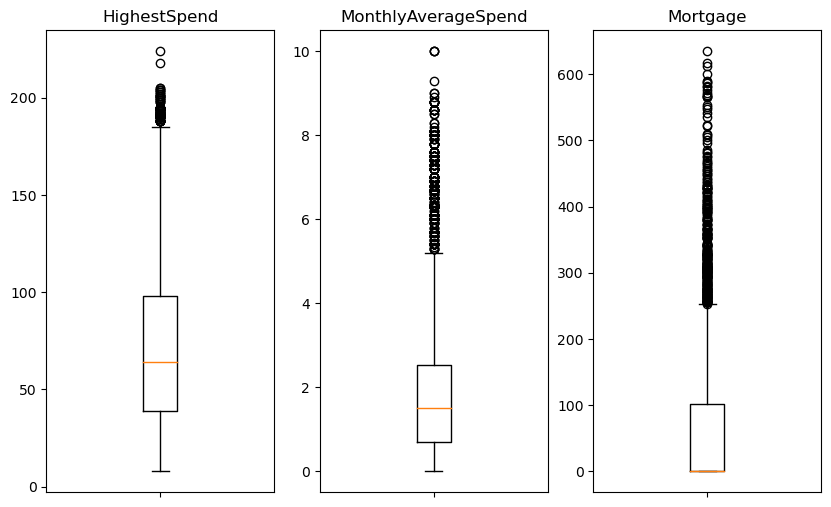

```python
features = ['HighestSpend', 'MonthlyAverageSpend', 'Mortgage']

# Create a figure and axes
fig, axes = plt.subplots(nrows=1, ncols=len(features), figsize=(10, 6))

# Iterate over the features
for i, feature in enumerate(features):
    # Create a boxplot for the current feature
    axes[i].boxplot(merged_df[feature])
    axes[i].set_title(feature)

# Set the x-axis tick labels
plt.setp(axes, xticks=[1], xticklabels=[''])


# Display the plot
plt.show()
```

```python
# Can clearly see there are outliers. Imputing them.
for c in ['HighestSpend', 'MonthlyAverageSpend', 'Mortgage']:
    q25, q75 = np.percentile(merged_df[c], 25), np.percentile(merged_df[c], 75)
    IQR = q75 - q25
    Threshold = IQR * 1.5
    lower, upper = q25 - Threshold, q75 + Threshold

    Outliers = [i for i in merged_df[c] if i < lower or i > upper]

    merged_df_include = merged_df.loc[(merged_df[c] >= lower) & (merged_df[c] <= upper)]
    mean = int(merged_df_include[c].mean())

    merged_df[c] = np.where(merged_df[c] > upper, mean, merged_df[c])
    merged_df[c] = np.where(merged_df[c] < lower, mean, merged_df[c])

    Outliers = [i for i in merged_df[c] if i < lower or i > upper]
```

Part 2.3 a- Split data into X and Y

Part 2.3 b - Split data into train and test. Keep 25% data reserved for testing

```python
X=merged_df.drop(columns='LoanOnCard')
y=merged_df['LoanOnCard'] #target

# Split X and y into training and test set in 70:30 ratio
X_train, X_test, y_train, y_test = train_test_split(X, y, test_size=0.25, random_state=10)
```

Part 2.3 c - Train a Supervised Learning Classification base model - Logistic Regression

```python
from sklearn.linear_model import LogisticRegression

logit = LogisticRegression()
logit.fit(X_train, y_train)
logit_pred = logit.predict(X_test)
```

Part 2.3 d - Print evaluation metrics for the model and clearly share insights

```python
print('Logistic regression - Accuracy on Training data:',logit.score(X_train, y_train))
print('Logistic regression - Accuracy on Test data:',logit.score(X_test, y_test))
```

```
Logistic regression - Accuracy on Training data: 0.9502008032128514
Logistic regression - Accuracy on Test data: 0.940562248995984
```

```
Confusion Matrix
```

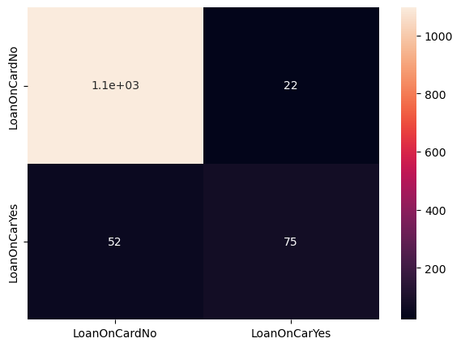

```python
print("Confusion Matrix")
cm=metrics.confusion_matrix(y_test, logit_pred, labels= [0,1])

df_cm = pd.DataFrame(cm, index = [i for i in ["LoanOnCardNo", "LoanOnCarYes"]],
                  columns = [i for i in ["LoanOnCardNo", "LoanOnCarYes"]])
plt.figure(figsize = (7,5))
sns.heatmap(df_cm, annot=True)
```

1. 52 & 22 are model errors

```python
print("classification  Matrix:\n",classification_report(y_test,logit_pred))
```

```
classification  Matrix:
               precision    recall  f1-score   support

         0.0       0.95      0.98      0.97      1118
         1.0       0.77      0.59      0.67       127

    accuracy                           0.94      1245
   macro avg       0.86      0.79      0.82      1245
weighted avg       0.94      0.94      0.94      1245
```

The metrics indicate that the model performs well with high precision, recall, and F1-score for class 0. However, for class 1, the performance is relatively lower, with lower precision, recall, and F1-score.

Part 2.3 e - Balance the data using the right balancing technique.

```python
# We will be doing oversampling using SMOTE
from imblearn.over_sampling import SMOTENC
smote = SMOTENC(categorical_features=[1,3,5],random_state=35)

# Apply SMOTE to generate synthetic samples
X_resampled, y_resampled = smote.fit_resample(X, y)
```

```python
#Before sampling
y.value_counts()
```

```
0.0    4500
1.0     480
Name: LoanOnCard, dtype: int64
```

```python
#After sampling
y_resampled.value_counts()
```

```
0.0    4500
1.0    4500
Name: LoanOnCard, dtype: int64
```

Part 2.3 f- Again train the same previous model on balanced data

```python
X_train_smot, X_test_smot, y_train_smot, y_test_smot = train_test_split(X_resampled, y_resampled, test_size=0.20, random_state=11)
```

```python
logit.fit(X_train_smot, y_train_smot)
logit_pred = logit.predict(X_test_smot)
```

Part 2.3 g- Print evaluation metrics and clearly share differences observed

```python
print('Logistic regression - Accuracy on Training data:',logit.score(X_train_smot, y_train_smot))
print('Logistic regression - Accuracy on Test data:',logit.score(X_test_smot, y_test_smot))
```

```
Logistic regression - Accuracy on Training data: 0.8766666666666667
Logistic regression - Accuracy on Test data: 0.8833333333333333
```

The accuracy is reduced.

```
Confusion Matrix
```

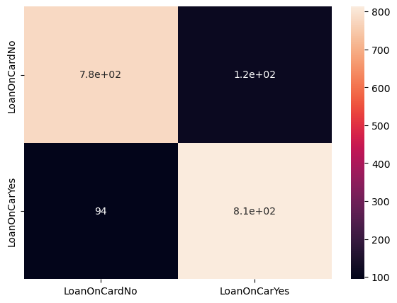

```python
print("Confusion Matrix")
cm=metrics.confusion_matrix(y_test_smot, logit_pred, labels= [0,1])

df_cm = pd.DataFrame(cm, index = [i for i in ["LoanOnCardNo", "LoanOnCarYes"]],
                  columns = [i for i in ["LoanOnCardNo", "LoanOnCarYes"]])
plt.figure(figsize = (7,5))
sns.heatmap(df_cm, annot=True)
```

```python
print("classification  Matrix:\n",classification_report(y_test_smot,logit_pred))
```

```
classification  Matrix:
               precision    recall  f1-score   support

         0.0       0.89      0.87      0.88       893
         1.0       0.88      0.90      0.89       907

    accuracy                           0.88      1800
   macro avg       0.88      0.88      0.88      1800
weighted avg       0.88      0.88      0.88      1800
```

We can see there is improvement in recall after sampling.

Although the accuracy is reduced.

Part 2.4 a- Train a base model each for SVM, KNN

Part 2.4 b - Tune parameters for each of the models wherever required and finalize a mode

Part 2.4 c- Print evaluation metrics for final mode

Part 2.4 d- Share improvement achieved from base model to final model

## SVM Model

```python
#Base model

# Split data into training and test sets
X_train, X_test, y_train, y_test = train_test_split(X, y, test_size=0.2, random_state=42)

# Initialize and train SVM model
svm = SVC()
svm.fit(X_train, y_train)

train_predictions = svm.predict(X_train)
train_accuracy = accuracy_score(y_train, train_predictions)
print("Train Accuracy:", train_accuracy)

test_predictions = svm.predict(X_test)
test_accuracy = accuracy_score(y_test, test_predictions)
print("Test Accuracy:", test_accuracy)
```

```
Train Accuracy: 0.9113955823293173
Test Accuracy: 0.9136546184738956
```

```python
report = classification_report(y_test, test_predictions)
print("Classification Report:")
print(report)
```

```
Classification Report:
              precision    recall  f1-score   support

         0.0       0.92      0.99      0.95       907
         1.0       0.56      0.17      0.26        89

    accuracy                           0.91       996
   macro avg       0.74      0.58      0.61       996
weighted avg       0.89      0.91      0.89       996
```

Based on the classification report, the model seems to perform well in terms of precision and recall for class 0.0, but it has lower performance for class 1.0.

```python
#Tuning hyper parameters to get better model
from sklearn.svm import SVC
from sklearn.ensemble import RandomForestClassifier
from sklearn.model_selection import GridSearchCV
svc = SVC()
param_grid = {
    'gamma': [0.1, 1, 10],
    'C': [0.1, 1, 10]
}

# Create the GridSearchCV object
clf = GridSearchCV(svc, param_grid, cv=5, scoring='accuracy')

# Fit the GridSearchCV object to the training data
clf.fit(X_train, y_train)

# Access the best hyperparameters
best_params = clf.best_params_
print(best_params)
```

```
{'C': 10, 'gamma': 0.1}
```

```python
# Initialize and train SVM model
svm = SVC(gamma=0.1, C=10)
svm.fit(X_train, y_train)

train_predictions = svm.predict(X_train)
train_accuracy = accuracy_score(y_train, train_predictions)
print("Train Accuracy:", train_accuracy)

test_predictions = svm.predict(X_test)
test_accuracy = accuracy_score(y_test, test_predictions)
print("Test Accuracy:", test_accuracy)
```

```
Train Accuracy: 0.9907128514056225
Test Accuracy: 0.9508032128514057
```

Clearly there is a increase in accuracy with the new model

```python
report = classification_report(y_test, test_predictions)
print("Classification Report:")
print(report)
```

```
Classification Report:
              precision    recall  f1-score   support

         0.0       0.96      0.99      0.97       907
         1.0       0.86      0.54      0.66        89

    accuracy                           0.95       996
   macro avg       0.91      0.77      0.82       996
weighted avg       0.95      0.95      0.95       996
```

The precision for class 0 (0.96) is higher than before (0.92), indicating a better ability to correctly classify instances as class 0.

The recall for class 0 (0.99) is the same as before (0.99), indicating that the model still captures a high percentage of actual class 0 instances.

The precision for class 1 (0.86) is higher than before (0.56), indicating a better ability to correctly classify instances as class 1.

The recall for class 1 (0.54) is higher than before (0.17), indicating that the model captures a higher percentage of actual class 1 instances.

The f1-score for both classes has improved, indicating a better balance between precision and recall.

## KNN Model

```python
from sklearn.preprocessing import StandardScaler, OneHotEncoder
from sklearn.compose import ColumnTransformer
from sklearn.neighbors import KNeighborsClassifier
from sklearn.model_selection import train_test_split
##Base Model


# Preprocess categorical features
categorical_features = X.select_dtypes(exclude=np.number)
numerical_features = X.select_dtypes(include=np.number)
encoder = OneHotEncoder()
categorical_features_encoded = encoder.fit_transform(categorical_features).toarray()

# Preprocess numerical features
scaler = StandardScaler()
numerical_features_scaled = scaler.fit_transform(numerical_features)

# Concatenate encoded categorical features and scaled numerical features
X_processed = pd.concat([pd.DataFrame(numerical_features_scaled, columns=numerical_features.columns),
                         pd.DataFrame(categorical_features_encoded, columns=encoder.get_feature_names())], axis=1)

# Split the data into training and testing sets
X_train, X_test, y_train, y_test = train_test_split(X_processed, y, test_size=0.2, random_state=42)

# Initialize and train the KNN classifier

# Create and train the KNN model
knn = KNeighborsClassifier(n_neighbors=5)  # You can specify the desired number of neighbors
knn.fit(X_train, y_train)

# Make predictions on train and test data
train_predictions = knn.predict(X_train)
test_predictions = knn.predict(X_test)

# Calculate accuracy on train and test data
train_accuracy = accuracy_score(y_train, train_predictions)
test_accuracy = accuracy_score(y_test, test_predictions)

print("Train Accuracy:", train_accuracy)
print("Test Accuracy:", test_accuracy)
print("Classification Report")
report = classification_report(y_test, test_predictions)
print(report)
```

```
Train Accuracy: 0.9791666666666666
Test Accuracy: 0.9728915662650602
Classification Report
              precision    recall  f1-score   support

         0.0       0.97      1.00      0.99       907
         1.0       0.98      0.71      0.82        89

    accuracy                           0.97       996
   macro avg       0.98      0.85      0.90       996
weighted avg       0.97      0.97      0.97       996
```

```python
# Changing the hyperparameters to get new model
# Create and train the KNN model
knn = KNeighborsClassifier(n_neighbors=5, weights='distance')  # You can specify the desired number of neighbors
knn.fit(X_train, y_train)

# Make predictions on train and test data
train_predictions = knn.predict(X_train)
test_predictions = knn.predict(X_test)

# Calculate accuracy on train and test data
train_accuracy = accuracy_score(y_train, train_predictions)
test_accuracy = accuracy_score(y_test, test_predictions)

print("Train Accuracy:", train_accuracy)
print("Test Accuracy:", test_accuracy)
print("Classification Report")
report = classification_report(y_test, test_predictions)
print(report)
```

```
Train Accuracy: 1.0
Test Accuracy: 0.9769076305220884
Classification Report
              precision    recall  f1-score   support

         0.0       0.98      1.00      0.99       907
         1.0       1.00      0.74      0.85        89

    accuracy                           0.98       996
   macro avg       0.99      0.87      0.92       996
weighted avg       0.98      0.98      0.98       996
```

The new model performs slightly better than the previous model, with improvements in test accuracy, precision, recall, and F1-score for class 1.0.